# Why experiment? | *Pourquoi faire des expériences ?*

Brice + Vin

2026-06-11

## Welcome

Welcome

*Bienvenue*

- Who we are, what EGAP is
- Introductions
- Qui sommes-nous, qu’est-ce qu’EGAP
- Présentations

## Welcome

Welcome

*Bienvenue*

- Goals of this workshop
  - Understand what an experiment is
  - Understand the main experimental design decisions
  - Understand how to analyze and interpret experimental data
  - Build communities of researchers and practitioners in Africa
- Structure
  - Combination of lectures
  - Exercises in class / Activities
- Objectifs de l’atelier
  - Comprendre ce qu’est une expérience
  - Comprendre les principales décisions d’un design expérimental
  - Comprendre comment analyser et interpréter des données expérimentales
  - Construire des communautés de chercheurs et de praticiens en Afrique
- Structure
  - Combinaison de cours magistraux
  - Exercices en classe / Activités

## Welcome

Welcome

*Bienvenue*

- Ground rules
  - We help each other: respectful communication
  - We all know this is often hard: Ask for help
  - Computers away except for exercises
- Resources
  - We will share resources on-line https://egap.github.io/learningdays-resources/abidjan_2026/
  - We will share resources on a thumb drive
- Règles de conduite
  - Communication respectueuse
  - Demandez de l’aide
  - Ordinateurs rangés sauf pour les exercices
- Ressources
  - Nous partagerons des ressources en ligne https://egap.github.io/learningdays-resources/abidjan_2026/
  - Nous partagerons des ressources sur une clé USB

## Key points for this lecture

Key points for this lecture

*Points clés du cours*

- What are the limitations of observational research?
- What is a randomized experiment?
- Who uses experiments?
- What are experiments good for (and not)?
- Quelles sont les limites des études observationnelles ?
- Qu’est-ce qu’une expérience aléatoire ?
- Qui utilise les expériences ?
- À quoi servent les expériences ?

## The big picture

The big picture

*La vue d’ensemble*

$$X \overset{?}{\rightarrow} Y$$

## What is X called? What is Y called?

What is X called? What is Y called?

*Comment appelle-t-on X ? Comment appelle-t-on Y ?*

$$X \overset{?}{\rightarrow} Y$$

- What is X called?
- What is Y called?
- Comment appelle-t-on X ?
- Comment appelle-t-on Y ?

## What is X called? What is Y called?

What is X called? What is Y called?

*Comment appelle-t-on X ? Comment appelle-t-on Y ?*

$$X \overset{?}{\rightarrow} Y$$

- **X**: independent variable, treatment
- **Y**: dependent variable, outcome variable
- **X** : variable indépendante, traitement
- **Y** : variable dépendante, variable de résultat

## What is the impact of decentralization on corruption?

What is the impact of decentralization on corruption?

*Quel est l’impact de la décentralisation sur la corruption ?*

- How would we try to answer that question?
- Comment y répondre ?

## Observational research: the usual approach

Observational research: the usual approach

*Études observationnelles : l’approche habituelle*

- Download and merge existing datasets
- Measure naturally occurring behaviors or outcomes, perhaps by running a survey
- Observe, don’t intervene or treat
- Télécharger et fusionner les bases de données existants
- Mesurer les comportements ou d’autres résultats, par exemple en menant un sondage
- On observe, sans intervenir ni traiter

## An observational study of decentralization

An observational study of decentralization

*Une étude observationnelle de la décentralisation*

- Fisman and Gatti (2002): “Decentralization and corruption: evidence across countries” (cited 2,423 times)
- Data from transparency international and IMF on 80 countries; OLS regression (with controls)
- Finds a strong country-level correlation between fiscal decentralization in government expenditure and lower corruption
- World Bank heavily promoted decentralization in the 1990s and 2000s
- Fisman et Gatti (2002) : “Decentralization and corruption: evidence across countries” (cité 2 423 fois)
- Données de Transparency International et du FMI sur 80 pays ; régressions MCO (avec variables de contrôle)
- Constate une forte corrélation au niveau des pays entre la décentralisation fiscale des dépenses publiques et une baisse de la corruption
- La Banque mondiale a fortement encouragé la décentralisation dans les années 1990 et 2000

## Should the World Bank believe that decentralization decreases corruption, based on Fisman and Gatti (2002)?

Should the World Bank believe that decentralization decreases corruption, based on Fisman and Gatti (2002)?

*La Banque mondiale devrait-elle croire que la décentralisation réduit la corruption ?*

- Countries that decentralize may
  - Be less corrupt to begin with
  - Have stronger civil societies
  - Adopt other governance reforms at the same time
- Les pays qui se décentralisent sont peut-être
  - moins touchés par la corruption dès le départ
  - dotés d’une société civile plus forte
  - susceptibles d’adopter d’autres réformes de gouvernance en parallèle

## Confounding

Confounding

*Facteurs de confusion*

- *Confounding*: a hidden factor that makes it look like there’s a causal effect when there might not be
- Observational research can show patterns and associations, but rarely causality
- *Facteurs de confusion* : facteur caché qui donne l’impression qu’il existe un lien de causalité alors qu’il n’y en a peut-être pas
- La recherche observationnelle permet de mettre en évidence des tendances et des associations, mais rarement des liens de causalité

## What is a randomized experiment?

What is a randomized experiment?

*Qu’est-ce qu’une expérience aléatoire ?*

- You have a treatment (intervention)
- *You randomly assign units to treatment and control conditions*
- You compare the outcomes for the units that were assigned to treatment to outcomes for those that were not
- Vous avez un traitement (intervention)
- *Vous répartissez aléatoirement les unités entre le groupe de traitement et le groupe témoin*
- Vous comparez les résultats des unités assignées au traitement à ceux des unités assignées au contrôle

## Randomized experiment diagram

Randomized experiment diagram

*Schéma d’une expérience aléatoire*

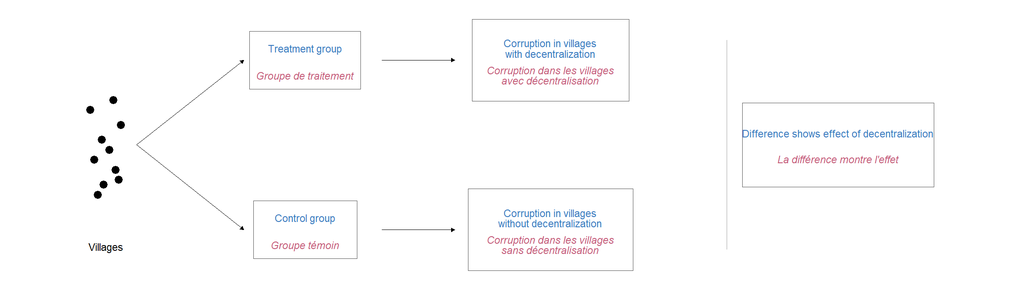

## Why an experiment?

Why an experiment?

*Pourquoi mener une expérience ?*

## Widespread use

Widespread use

*Utilisation répandue*

- Clinical trials for medicine
- Political campaigns
- Tech A/B testing
- Policy trials in governments
- Essais cliniques
- Campagnes politiques
- Tests A/B en tech
- Expérimentations de politiques publiques au sein des gouvernements

## Use in social science

Use in social science

*Utilisation en sciences sociales*

- Corrected wrong beliefs
- Found that some things don’t scale
- Encouraged good policies
- Corrigé certaines idées fausses
- montré que certaines choses ne sont pas transposables à plus grande échelle
- favorisé la mise en place de bonnes politiques publiques

## Proving beliefs wrong

Proving beliefs wrong

*Corriger certaines idées fausses*

- Belief: Microfinance boosts poverty reduction
- Multiple studies have randomized microcredit at the group or neighborhood level
- Result: No impact on household income, consumption, or women’s empowerment
- Idée reçue : la microfinance favorise la réduction de la pauvreté
- De nombreuses études ont mis en place des programmes de microcrédit de manière aléatoire
- Résultat : aucun impact sur les revenus des ménages, la consommation ou l’autonomisation des femmes

## Proving beliefs right

Proving beliefs right

*Valider les croyances*

- Belief: Conditional cash transfers improve school attendance
- Study: PROGRESA in Mexico randomized whether families were paid to keep children in school
- Result: Large increases in enrollment, especially for girls and secondary students
- Idée reçue : Les transferts monétaires conditionnels augmentent la fréquentation scolaire
- Étude : Le programme PROGRESA au Mexique a randomisé le versement d’allocations aux familles pour maintenir leurs enfants à l’école
- Résultat : Forte hausse des inscriptions, en particulier pour les filles et les élèves du secondaire

## Limitations to experiments

Limitations to experiments

*Limites des expériences*

- Some things don’t need an experiment (smoking and parachutes)
- Some experiments aren’t ethical
- Some interventions can’t be randomized
- Certaines choses ne nécessitent pas d’expérience (le tabac et les parachutes)
- Certaines expériences ne sont pas éthiques
- Certaines interventions ne peuvent pas être randomisées

## Why experiments

Why experiments

*Pourquoi des expérimentations ?*

- Let’s put beliefs to the test
- What works? $\rightarrow$ Let’s find out!
- Mettons nos convictions à l’épreuve
- Qu’est-ce qui fonctionne ? $\rightarrow$ Découvrons-le !